# Data Science Capstone Week 2 Milestone Report

YH

11/03/2020

### Introduction

###### This is the Week2 milestone report of Coursera Data Science Capstone course.

###### In this Report, the main goal is to build the first simple model for the relationship between words. This is the first step in building a predictive text mining application. The data is from three sources: blog, news and twitter in English(US).

### Read in data and load required library

```r
#Load library
  library(quanteda)
  library(readtext)
  library(knitr)
  library(kableExtra)
  library(tm)
  library(ggplot2)

#Read in data
  add_blog<-"final/en_US/en_US.blogs.txt"
  add_news<-"final/en_US/en_US.news.txt"
  add_twitter<-"final/en_US/en_US.twitter.txt"
  file_blog<-readLines(con=add_blog)
  file_news<-readLines(con=add_news)
  file_twitter<-readLines(con=add_twitter)

#Clean up data by removing all the non-English words from the file
  file_blog <- iconv(file_blog, "latin1", "ASCII", sub="")
  file_news <- iconv(file_news, "latin1", "ASCII", sub="")
  file_twitter <- iconv(file_twitter, "latin1", "ASCII", sub="")
```

### An overview on the basic information of the files

###### Here I explore the general information of the three data files

```r
summary_basic<-rbind(summary(nchar(file_blog)),
                     summary(nchar(file_news)),
                     summary(nchar(file_twitter)))
row.names(summary_basic)<-c("blog","news","twitter")
colnames(summary_basic)<-sapply(colnames(summary_basic),function(x)paste("nchar.",x,collapse = ""))
summary_basic<-as.data.frame(summary_basic)
Size.MB<-c(file.info(add_blog)$size/1000000,
        file.info(add_news)$size/1000000,
        file.info(add_twitter)$size/1000000)
No.Line<-c(length(file_blog),
           length(file_news),
           length(file_twitter))
summary_basic<-cbind(summary_basic,Size.MB,No.Line)
kable(summary_basic, caption = "An overview on the three text files") %>% kable_styling()
```

An overview on the three text files

|  | nchar. Min. | nchar. 1st Qu. | nchar. Median | nchar. Mean | nchar. 3rd Qu. | nchar. Max. | Size.MB | No.Line |
| --- | --- | --- | --- | --- | --- | --- | --- | --- |
| blog | 0 | 46 | 155 | 229.11893 | 327 | 40832 | 210.1600 | 899288 |
| news | 1 | 110 | 185 | 202.11934 | 269 | 5760 | 205.8119 | 77259 |
| twitter | 2 | 37 | 64 | 68.62339 | 100 | 140 | 167.1053 | 2360148 |

### sampling and combining data

###### Given that the size of the data is really big, I would only use a subset of the data with random sampling for the following analyzing.

```r
#Set the size of sampling I would like to use
  size<-0.05
#Set seed to make the random sampling reproducible
  set.seed(420)
#Take samples from each source, combine and create a corpus object using quanteda package.
  corpus_all<-corpus(c(sample(file_blog,length(file_blog)*size),
                     sample(file_news,length(file_news)*size),
                     sample(file_twitter,length(file_twitter)*size)))
head(summary(corpus_all),5)
```

```
##    Text Types Tokens Sentences
## 1 text1    30     42         2
## 2 text2    21     28         3
## 3 text3    61     78         3
## 4 text4    71    135         4
## 5 text5     4     12         3
```

### Construct tokens and generate n-grams

###### After that, n-grams (n=1-3) were generated and ready to be analyzed or visualized in the next section.

```r
#Construct tokens
  tokens<-tokens(corpus_all,
                 remove_punct = TRUE,
                 remove_numbers = TRUE,
                 remove_url = TRUE,
                 remove_symbols = TRUE)
  tokens_clean<-tokens_wordstem(tokens_tolower(tokens))

#Generate n-grams and stored in variables
  tokens_1<-tokens_ngrams(tokens_clean, n=1)
  tokens_2<-tokens_ngrams(tokens_clean, n=2)
  tokens_3<-tokens_ngrams(tokens_clean, n=3)

#Convert the tokens to document-feature matrix (DFM) format so that ithey are prepared to be passed onto other functiions in the package for analysis.
  dfm_1<-dfm(tokens_1)
  dfm_2<-dfm(tokens_2)
  dfm_3<-dfm(tokens_3)
```

### Visualize results

###### In this section, I analyze the frequencies of the n-grams and plot the histogram.

###### The word cloud plots are for non-data scientist to understand the results of the analysis

##### a. n-grams frequency count

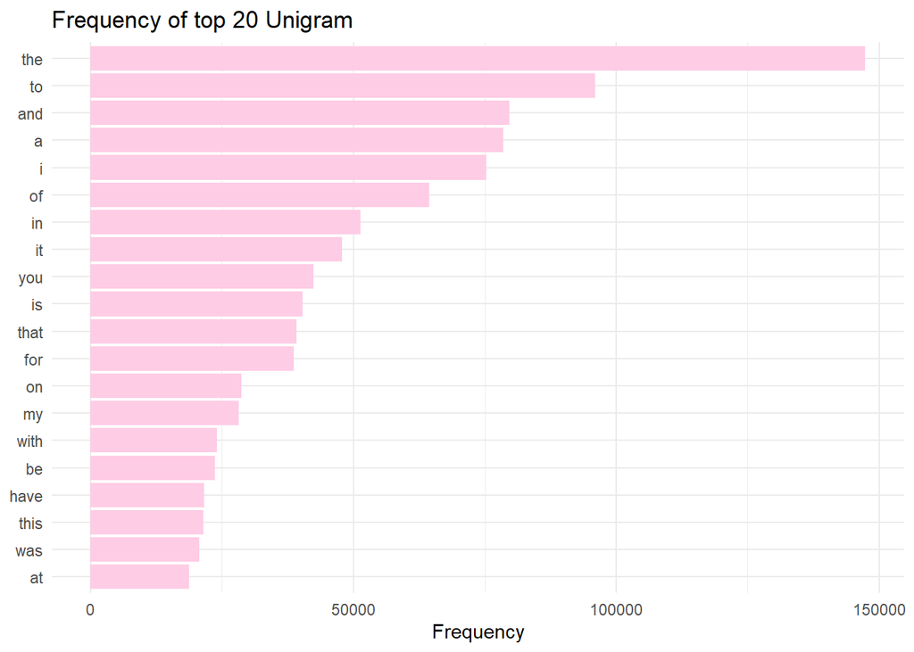

```r
#Count frequencies of the top 20 n-grams
  tsfq_1 <- textstat_frequency(dfm_1, n = 20)
  tsfq_2 <- textstat_frequency(dfm_2, n = 20)
  tsfq_3 <- textstat_frequency(dfm_3, n = 20)

#Plot the frequencies into bar charts
  ggplot(data=tsfq_1, aes(x = reorder(feature, frequency), y = frequency)) +
    geom_bar(stat="identity",fill="#FFCCE5") +
    coord_flip() +
    labs(x = NULL, y = "Frequency") +
    theme(legend.position = "none") +
    ggtitle("Frequency of top 20 Unigram") +
    theme_minimal()
```

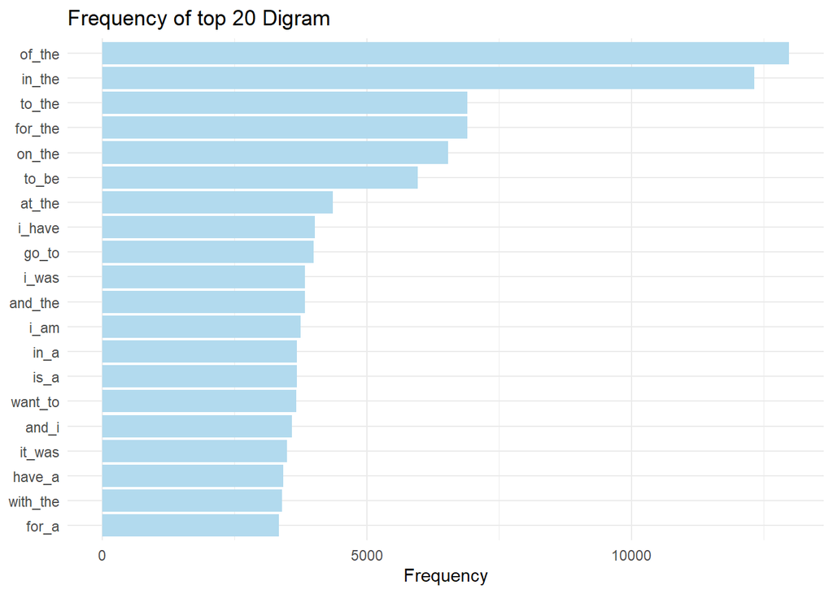

```r
  ggplot(data=tsfq_2, aes(x = reorder(feature, frequency), y = frequency)) +
    geom_bar(stat="identity",fill="#B2DAEE") +
    coord_flip() +
    labs(x = NULL, y = "Frequency") +
    theme(legend.position = "none") +
    ggtitle("Frequency of top 20 Digram") +
    theme_minimal()
```

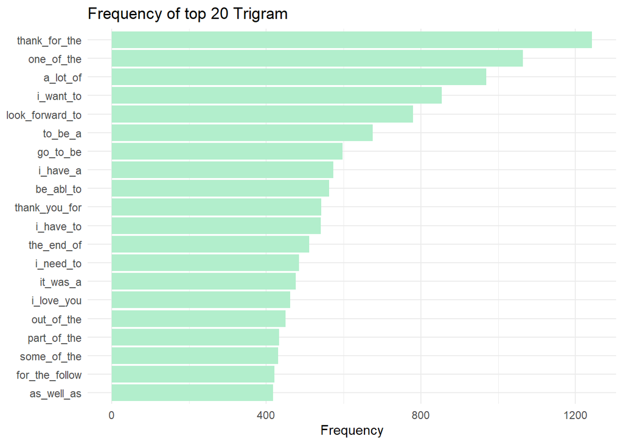

```r
  ggplot(data=tsfq_3, aes(x = reorder(feature, frequency), y = frequency)) +
    geom_bar(stat="identity",fill="#B2EECC") +
    coord_flip() +
    labs(x = NULL, y = "Frequency") +
    theme(legend.position = "none") +
    ggtitle("Frequency of top 20 Trigram") +
    theme_minimal()
```

##### b.Word clouds

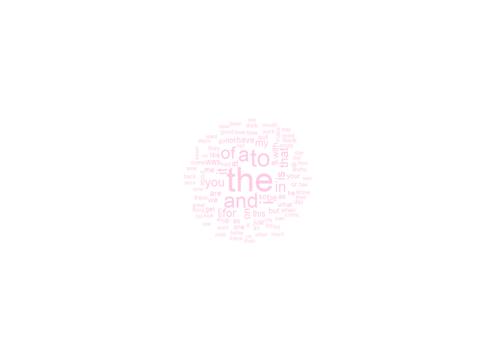

```r
#Plot wordclouds for the top 100 n-grams with highest frequencies
  textplot_wordcloud(dfm_1, max_words = 100, color = "#FFCCE5")
```

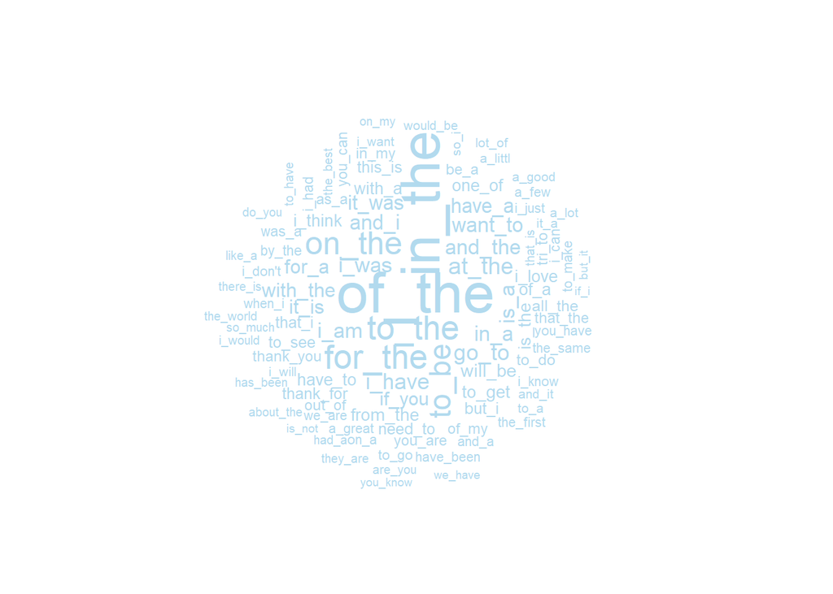

```r
  textplot_wordcloud(dfm_2, max_words = 100, color = "#B2DAEE")
```

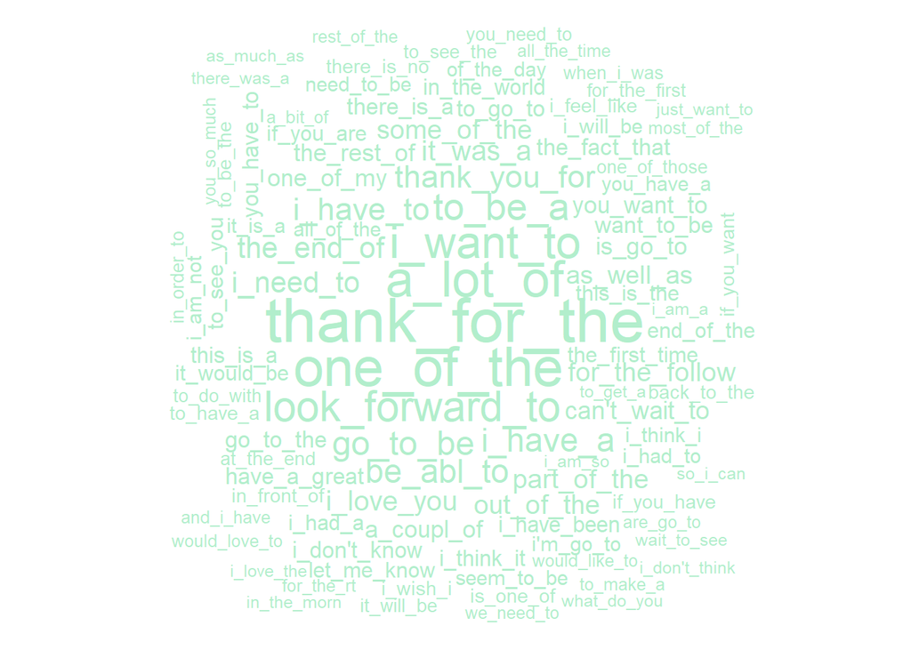

```r
  textplot_wordcloud(dfm_3, max_words = 100, color = "#B2EECC")
```

### Next step

###### With the tokens and n-grams generate in this report, we will be able to build a predictive model. The idea is that given the first 1 or 2 words provided, we will be able to identify the n-grams that have the highest frequency, and thus the most possible word come up next.

###### These data will then be passed onto a shiny app which users can handle easily.